# Week 2 Reproducible research assignment

First, we read in the csv file and perform some pre-processing

```r
library("data.table")
library(ggplot2)
```

```r
##read in the data and some pre pocessing

myfile <- read.csv("C:/Users/CVSSP/Desktop/R Programming/activity.csv")
Date <- as.Date(myfile$date)
myfile$date= NULL
myfile$Date <- Date
myfile$day <- weekdays(Date)
```

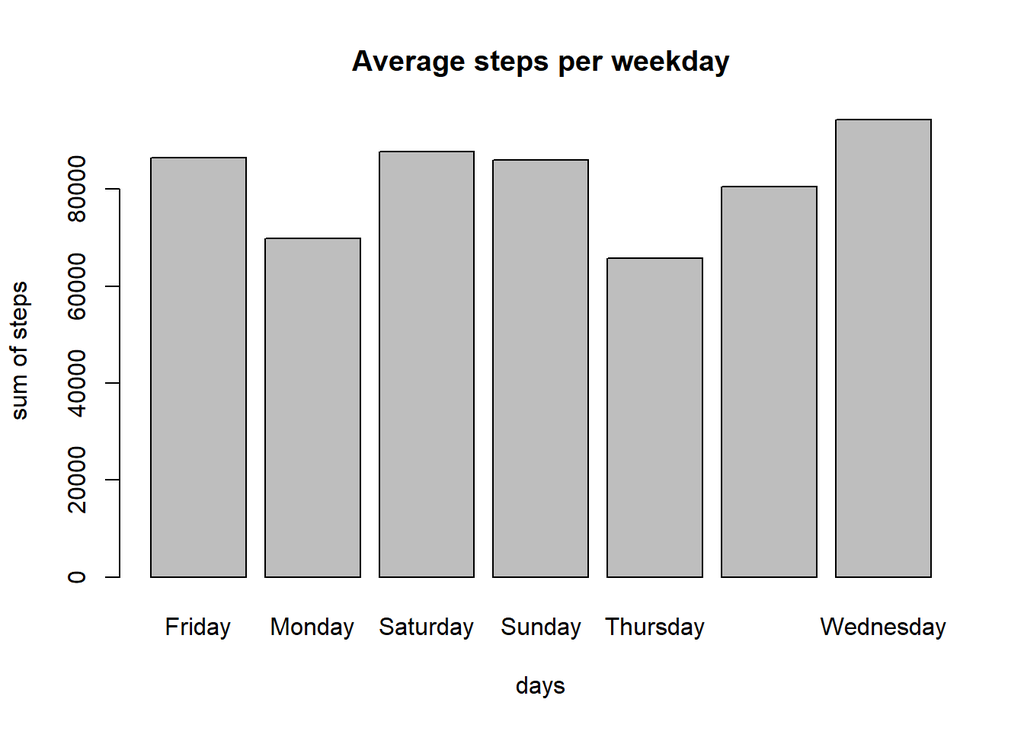

```r
mydata= aggregate(x= myfile$steps, by= list(myfile$day), FUN= sum, na.rm = TRUE)
names= mydata$Group.1
barplot(mydata$x,main = "Average steps per weekday", names.arg = names, xlab = "days", ylab = "sum of steps")
```

```r
mean(mydata$x)
```

```
## [1] 81515.43
```

```r
median(mydata$x)
```

```
## [1] 85944
```

To plot a time series chart of all the different time intervals along with the interval with the max steps

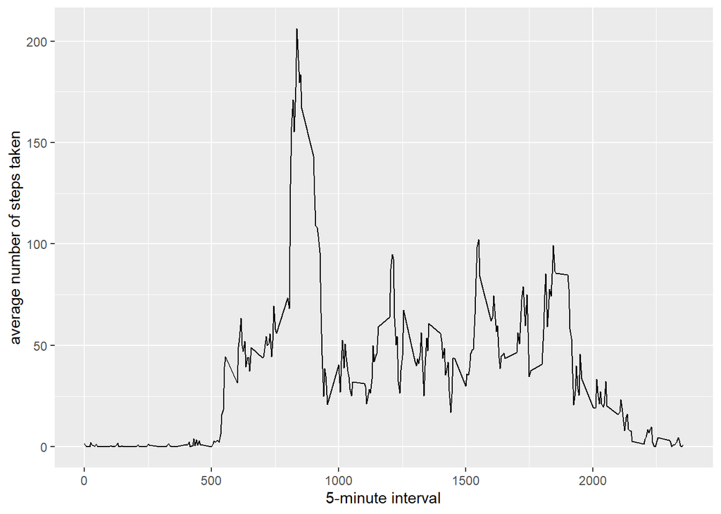

```r
library(ggplot2)
averages <- aggregate(x=list(steps=myfile$steps), by=list(interval=myfile$interval),
                      FUN=mean, na.rm=TRUE)
ggplot(data=averages, aes(x=interval, y=steps)) +
    geom_line() +
    xlab("5-minute interval") +
    ylab("average number of steps taken")
```

```r
averages[which.max(averages$steps),]  ## to find the interval with the highest number of steps
```

```
##     interval    steps
## 104      835 206.1698
```

Now we will consider the NA values and the effect they have on our analysis. To count the number of NA values:

```r
sum(is.na(myfile))
```

```
## [1] 2304
```

Next we devise a way to fill in the missing data

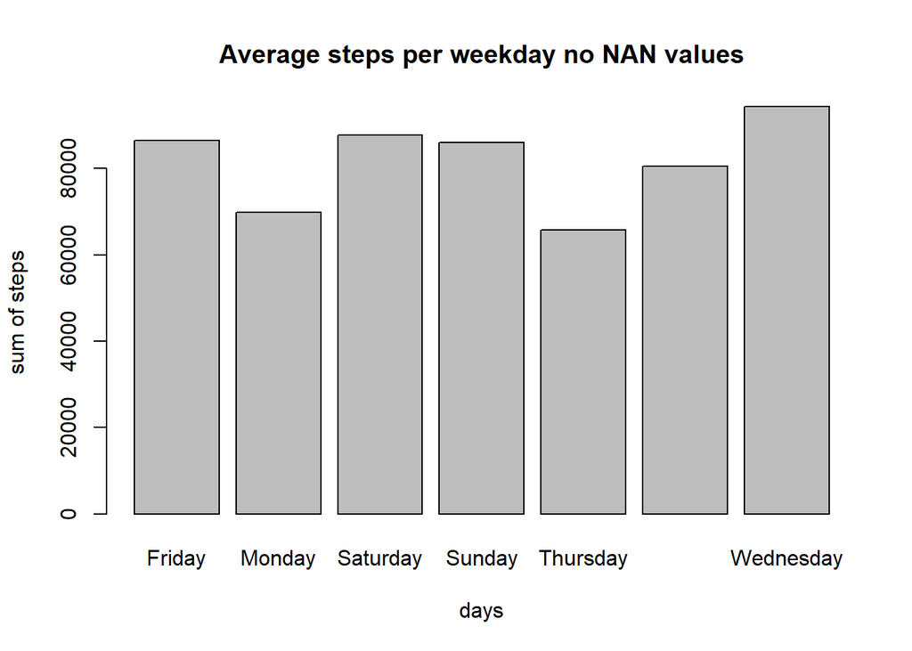

```r
myfile$steps[is.na(myfile$steps)]<-mean(mydata$x,na.rm=TRUE)
barplot(mydata$x,main = "Average steps per weekday no NAN values", names.arg = names, xlab = "days", ylab = "sum of steps")
```

```r
mean(mydata$x)
```

```
## [1] 81515.43
```

```r
median(mydata$x)
```

```
## [1] 85944
```

Finally, we compare activity levels on weekends vs weekdays

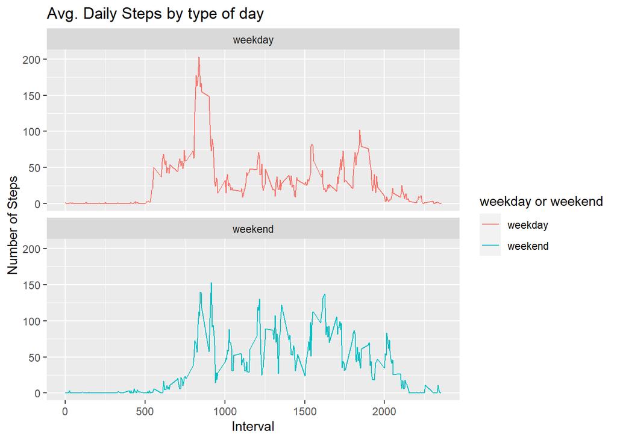

```r
q4database <- data.table::fread(input = "C:/Users/CVSSP/Desktop/R Programming/activity.csv")
q4database[, date := as.POSIXct(date, format = "%Y-%m-%d")]
q4database[, `Day of Week`:= weekdays(x = date)]
q4database[grepl(pattern = "Monday|Tuesday|Wednesday|Thursday|Friday", x = `Day of Week`), "weekday or weekend"] <- "weekday"
q4database[grepl(pattern = "Saturday|Sunday", x = `Day of Week`), "weekday or weekend"] <- "weekend"
q4database[, `weekday or weekend` := as.factor(`weekday or weekend`)]

q4database[is.na(steps), "steps"] <- q4database[, c(lapply(.SD, median, na.rm = TRUE)), .SDcols = c("steps")]
IntervalDT <- q4database[, c(lapply(.SD, mean, na.rm = TRUE)), .SDcols = c("steps"), by = .(interval, `weekday or weekend`)]

ggplot(IntervalDT , aes(x = interval , y = steps, color=`weekday or weekend`)) + geom_line() + labs(title = "Avg. Daily Steps by type of day", x = "Interval", y = "Number of Steps") + facet_wrap(~`weekday or weekend` , ncol = 1, nrow=2)
```

Overall, there is a noticable difference between activity on weekdays and weekends where till 08:00 AM on weekends the activity is considerably less. However, through the rest of the day activity on average is more than that on weekdays.